# Final Project

Samruddhi Shinde

5/1/2021

Loading packages

```r
library(here)
library(tidyverse)
```

Loading in Dataset

```r
covid_prison_cases <- read_csv(here("data", "covid_prison_cases.csv"))
```

This dataset explores COVID-19 data in prisons across the United States.

Data Set of Covid-19 Cases for every State in March 2021

```r
march2021_covid_cases <- covid_prison_cases %>%
  filter(as_of_date == "03/01/2021"|
        as_of_date =="03/02/2021"|
        as_of_date =="03/03/2021"|
        as_of_date == "03/04/2021"|
        as_of_date =="03/05/2021")
```

Bar plot Covid-19 Cases for every State in March 2021

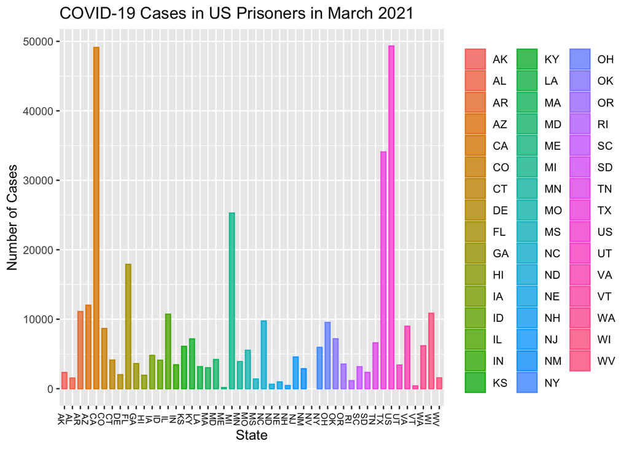

```r
march2021_covid_cases %>%
  ggplot(aes
         (x = abbreviation,
          y = total_prisoner_cases,
          color = abbreviation,
           fill = abbreviation)) +
  geom_bar(stat="identity", alpha=.8, width=.6) +
  theme(axis.text.x  = element_text(angle=-90, hjust=0.5, size=7,colour="black")) +
  ggtitle("COVID-19 Cases in US Prisoners in March 2021") +
  ylab("Number of Cases") +
  xlab("State") +
  theme(legend.title = element_blank())
```

This bar graph shows that California and federal prisons had the highest cases of COVID-19 in prisoners in March 2021.

```r
us_covid_stats <- march2021_covid_cases %>%
  summarize(Average_Staff_Cases = mean(total_staff_cases, na.rm = TRUE),
            Min_Staff_Cases = min(total_staff_cases, na.rm = TRUE),
            Max_Staff_Cases = max(total_staff_cases, na.rm = TRUE),
            Average_Staff_Deaths = mean(total_staff_deaths, na.rm = TRUE),
            Min_Staff_Deaths = min(total_staff_deaths, na.rm = TRUE),
            Max_Staff_Deaths = max(total_staff_deaths, na.rm = TRUE),
            Average_Prisoner_Cases = mean(total_prisoner_cases, na.rm = TRUE),
            Min_Prisoner_Cases = min(total_prisoner_cases, na.rm = TRUE),
            Maz_Prisoner_Cases = max(total_prisoner_cases, na.rm = TRUE),
            Average_Prisoner_Deaths = mean(total_prisoner_deaths, na.rm = TRUE),
            Min_Prisoner_Deaths = min(total_prisoner_deaths, na.rm = TRUE),
            Max_Prisoner_Deaths = max(total_prisoner_deaths, na.rm = TRUE))

tibble(us_covid_stats)
```

| Average_Staff_Cases | Min_Staff_Cases | Max_Staff_Cases | Average_Staff_Deaths | Min_Staff_Deaths | Max_Staff_Deaths | Average_Prisoner_Cases | Min_Prisoner_Cases | Maz_Prisoner_Cases | Average_Prisoner_Deaths | Min_Prisoner_Deaths | Max_Prisoner_Deaths |
| --- | --- | --- | --- | --- | --- | --- | --- | --- | --- | --- | --- |
| 2217.023 | 57 | 15810 | 4.75 | 0 | 41 | 7886.723 | 157 | 49324 | 49.26087 | 1 | 239 |

This table shows that on average, prisoners have higher case & death rates compared to staff.

Filtering the covid_prison_cases dataset for California statistics Also only looking at staff & prisoner cases/deaths

```r
cali_covid_cases <- covid_prison_cases %>%
  filter(name == "California") %>%
  select(total_staff_cases, total_staff_deaths, total_prisoner_cases, total_prisoner_deaths, as_of_date)
```

```r
cali_covid_stats <- cali_covid_cases %>%
  summarize(Average_Staff_Cases = mean(total_staff_cases, na.rm = TRUE),
            Min_Staff_Cases = min(total_staff_cases, na.rm = TRUE),
            Max_Staff_Cases = max(total_staff_cases, na.rm = TRUE),
            Average_Staff_Deaths = mean(total_staff_deaths, na.rm = TRUE),
            Min_Staff_Deaths = min(total_staff_deaths, na.rm = TRUE),
            Max_Staff_Deaths = max(total_staff_deaths, na.rm = TRUE),
            Average_Prisoner_Cases = mean(total_prisoner_cases, na.rm = TRUE),
            Min_Prisoner_Cases = min(total_prisoner_cases, na.rm = TRUE),
            Maz_Prisoner_Cases = max(total_prisoner_cases, na.rm = TRUE),
            Average_Prisoner_Deaths = mean(total_prisoner_deaths, na.rm = TRUE),
            Min_Prisoner_Deaths = min(total_prisoner_deaths, na.rm = TRUE),
            Max_Prisoner_Deaths = max(total_prisoner_deaths, na.rm = TRUE))

tibble(cali_covid_stats)
```

| Average_Staff_Cases | Min_Staff_Cases | Max_Staff_Cases | Average_Staff_Deaths | Min_Staff_Deaths | Max_Staff_Deaths | Average_Prisoner_Cases | Min_Prisoner_Cases | Maz_Prisoner_Cases | Average_Prisoner_Deaths | Min_Prisoner_Deaths | Max_Prisoner_Deaths |
| --- | --- | --- | --- | --- | --- | --- | --- | --- | --- | --- | --- |
| 5035.143 | 9 | 15810 | 8.408163 | 0 | 26 | 16996.36 | 1 | 49115 | 71.96 | 0 | 212 |

This table shows that on average, prisoners in California have higher case & death rates compared to staff.

Filtering data to only look at 2020 cases

```r
cali_2020covid_cases <- cali_covid_cases[-c(1:9),]
```

Scatter Plot for total prisoner cases per date

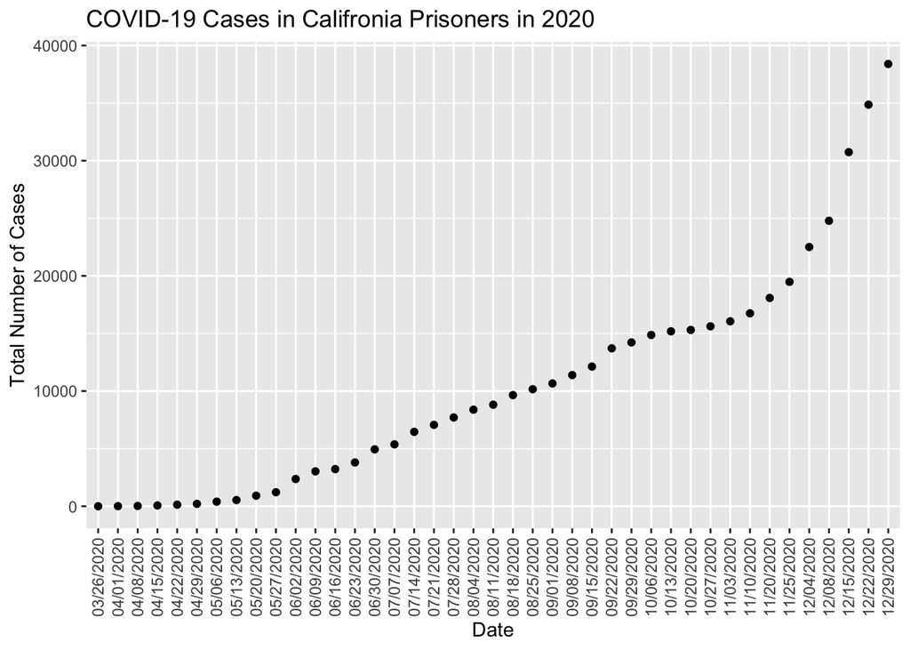

```r
cali_2020covid_cases %>%
  ggplot(aes
         (x = as_of_date,
           y = total_prisoner_cases)) +
  geom_point() +
  theme(axis.text.x = element_text(angle = 90, vjust = 0.5, hjust=1)) +
  ggtitle("COVID-19 Cases in Califronia Prisoners in 2020") +
  ylab("Total Number of Cases") +
  xlab("Date")
```

This scatter plot shows the trend of increasing COVID-19 cases in prisoners during 2020.